# Multiple Linear Regression Implementation in R

### Setting the WD

```r
setwd("D:/Dropbox/Clases/Udemy/Machine Learning A-Z/Part 2 - Regression/Section 5 - Multiple Linear Regression")
```

```
The working directory was changed to D:/Dropbox/Clases/Udemy/Machine Learning A-Z/Part 2 - Regression/Section 5 - Multiple Linear Regression inside a notebook chunk. The working directory will be reset when the chunk is finished running. Use the knitr root.dir option in the setup chunk to change the…
```

### Data Preprocessing

We will be using the same data preprocessing template used in previous excercises: A few things to remember:

- Shince there is a variable with categorical values it has to be encoded.
- There is no need to do feature scaling since the function used in R will take care of that already.

```r
# Data Preprocessing template

# Importing the dataset
dataset = read.csv('50_Startups.csv')
# dataset = dataset[, 2:3]

#Encoding Categorical Data, this is important because a regression model cannot work with categorical values.
dataset$State <- factor(dataset$State,
                        levels = c('New York', 'California', 'Florida'),
                        labels = c(1, 2, 3))

# Splitting the dataset into the Training set and Test set
# install.packages('caTools')
library(caTools)
set.seed(123)
split = sample.split(dataset$Profit, SplitRatio = 0.8)
training_set = subset(dataset, split == TRUE)
test_set = subset(dataset, split == FALSE)

# Feature Scaling
# training_set[, 2:3] = scale(training_set[, 2:3])
# test_set[, 2:3] = scale(test_set[, 2:3])
```

### Fitting Multiple Linear Regression to the Training Set

First a `regressor` has to be generated to fit the training set, later on it will be used in the process.

```r
#regressor <- lm(formula = Profit ~ R.D.Spend + Administration + Marketing.Spend + State)
regressor <- lm(formula = Profit ~ . , #Using the . tells R to add all the independent variables.
                data = training_set)
```

### Generating the `regressor`

Taking a look at the `regressor` just generated can be done with the comand `summary()`, this will start showing us important imformation regarding the influence independent variables might have on the dependent one.

```r
summary(regressor)
```

```
Call:
lm(formula = Profit ~ ., data = training_set)

Residuals:
   Min     1Q Median     3Q    Max
-33128  -4865      5   6098  18065

Coefficients:
                  Estimate Std. Error t value Pr(>|t|)
(Intercept)      4.965e+04  7.637e+03   6.501 1.94e-07 ***
R.D.Spend        7.986e-01  5.604e-02  14.251 6.70e-16 ***
Administration  -2.942e-02  5.828e-02  -0.505    0.617
Marketing.Spend  3.268e-02  2.127e-02   1.537    0.134
State2           1.213e+02  3.751e+03   0.032    0.974
State3           2.376e+02  4.127e+03   0.058    0.954
---
Signif. codes:  0 ‘***’ 0.001 ‘**’ 0.01 ‘*’ 0.05 ‘.’ 0.1 ‘ ’ 1

Residual standard error: 9908 on 34 degrees of freedom
Multiple R-squared:  0.9499,    Adjusted R-squared:  0.9425
F-statistic:   129 on 5 and 34 DF,  p-value: < 2.2e-16
```

Some important things to notice:

- R has already taken care of the *dummy variable* creation for `State`.
- R has also staid out of the **dummy variable trap** and kept one of the tree generated out of the calculations.

### Predicting the `test_set` Results

```r
y_pred <- predict(regressor, newdata = test_set)
```

### **Backward Elimination**

Once a MLR model is done, it can be optimized through backward elimination, this doucment shows how to do this process in R.

We will be following the seps outlined in the following picture:

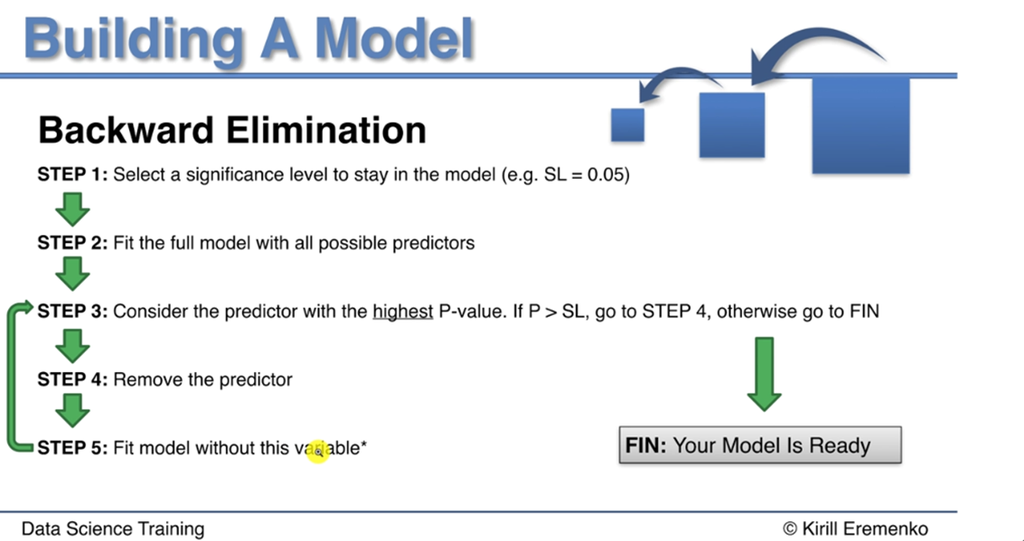

### Step 1 & 2

```r
regressor <- lm(formula = Profit ~ R.D.Spend + Administration + Marketing.Spend + State,
                data = dataset) #In this case the whole dataset is being used, training_set can also be used.
summary(regressor)
```

```
Call:
lm(formula = Profit ~ R.D.Spend + Administration + Marketing.Spend +
    State, data = dataset)

Residuals:
   Min     1Q Median     3Q    Max
-33504  -4736     90   6672  17338

Coefficients:
                  Estimate Std. Error t value Pr(>|t|)
(Intercept)      5.008e+04  6.953e+03   7.204 5.76e-09 ***
R.D.Spend        8.060e-01  4.641e-02  17.369  < 2e-16 ***
Administration  -2.700e-02  5.223e-02  -0.517    0.608
Marketing.Spend  2.698e-02  1.714e-02   1.574    0.123
State2           4.189e+01  3.256e+03   0.013    0.990
State3           2.407e+02  3.339e+03   0.072    0.943
---
Signif. codes:  0 ‘***’ 0.001 ‘**’ 0.01 ‘*’ 0.05 ‘.’ 0.1 ‘ ’ 1

Residual standard error: 9439 on 44 degrees of freedom
Multiple R-squared:  0.9508,    Adjusted R-squared:  0.9452
F-statistic: 169.9 on 5 and 44 DF,  p-value: < 2.2e-16
```

### Step 3 & 4

- By looking at the `summary(regressor)` results, we can see that the predictor (*independent variable*) with the highest *P* value is `State2` which means **California**. `State3` is the second highest *P* value and there is no way that it will become statistically significant by removing only one. This allows us to remove the variable `State` from the model and run step 5.

### Step 5

Fitting the model without the variable `State`:

```r
regressor <- lm(formula = Profit ~ R.D.Spend + Administration + Marketing.Spend,
                data = dataset) #In this case the whole dataset is being used, training_set can also be used.
summary(regressor)
```

```
Call:
lm(formula = Profit ~ R.D.Spend + Administration + Marketing.Spend,
    data = dataset)

Residuals:
   Min     1Q Median     3Q    Max
-33534  -4795     63   6606  17275

Coefficients:
                  Estimate Std. Error t value Pr(>|t|)
(Intercept)      5.012e+04  6.572e+03   7.626 1.06e-09 ***
R.D.Spend        8.057e-01  4.515e-02  17.846  < 2e-16 ***
Administration  -2.682e-02  5.103e-02  -0.526    0.602
Marketing.Spend  2.723e-02  1.645e-02   1.655    0.105
---
Signif. codes:  0 ‘***’ 0.001 ‘**’ 0.01 ‘*’ 0.05 ‘.’ 0.1 ‘ ’ 1

Residual standard error: 9232 on 46 degrees of freedom
Multiple R-squared:  0.9507,    Adjusted R-squared:  0.9475
F-statistic:   296 on 3 and 46 DF,  p-value: < 2.2e-16
```

### Iteration Steps

Fitting the model without `State` and moving on with the iteration steps shown on the previous picture takes us to make the following changes:

1. Take out the variable `Administration` since it’s *P* value is = 0.602.
2. Fit the model without the variable:

```r
regressor <- lm(formula = Profit ~ R.D.Spend + Marketing.Spend,
                data = dataset) #In this case the whole dataset is being used, training_set can also be used.
summary(regressor)
```

```
Call:
lm(formula = Profit ~ R.D.Spend + Marketing.Spend, data = dataset)

Residuals:
   Min     1Q Median     3Q    Max
-33645  -4632   -414   6484  17097

Coefficients:
                 Estimate Std. Error t value Pr(>|t|)
(Intercept)     4.698e+04  2.690e+03  17.464   <2e-16 ***
R.D.Spend       7.966e-01  4.135e-02  19.266   <2e-16 ***
Marketing.Spend 2.991e-02  1.552e-02   1.927     0.06 .
---
Signif. codes:  0 ‘***’ 0.001 ‘**’ 0.01 ‘*’ 0.05 ‘.’ 0.1 ‘ ’ 1

Residual standard error: 9161 on 47 degrees of freedom
Multiple R-squared:  0.9505,    Adjusted R-squared:  0.9483
F-statistic: 450.8 on 2 and 47 DF,  p-value: < 2.2e-16
```

```r
y_pred <- predict(regressor, newdata = test_set)
```

**I decided to keep `Marketing.Spend` because I think it gives me results closer to the real `test_set` results.**